# Modal Truncated Weibull (MTW)

This repository contains the code and simulations used in the article associated with the new modal regression based on Weibull truncated distribution, including applications and a simulation study.

## Applications

- **USA_election/**: Analysis and modeling of the 2016 U.S. election dataset.
- **Simulation/**: Monte Carlo simulations comparing the performance of models under different conditions.

## How to reproduce the results

1. Clone or download this repository.
2. Open the `MTWR.Rproj` file in RStudio.
3. Install the required R packages (see next section).
4. Run the script corresponding to the section of interest:
   - `USA_election/main_USA.R`
   - `Simulation/R/results_scenarioA.R`
   - `Simulation/R/results_scenarioB.R`

## Required R packages

Each script in this project loads the packages it needs. Below is the full list of R packages used:

- tidyverse (includes ggplot2, dplyr, tidyr, purrr, etc.)
- here
- VGAM
- betareg
- hnp
- MASS
- maxLik
- car
- Formula
- moments
- xtable
- ggthemes
- PNWColors
- usmap
- Stat2Data

```r
install.packages(c(
  "VGAM", "tidyverse", "hnp", "betareg", "Stat2Data", "usmap",
  "PNWColors", "car", "ggthemes", "MASS", "reshape2", "reshape", "maxLik", "here"
))
```

## Data

- The `USA_election` folder uses the **Election16** and **statepop** datasets from the **Stat2Data** and **usmap** packages.
- Simulated datasets are generated within the `Simulation/`.

## Example

This section presents an example using the **modal truncated Weibull** distribution in the context of modeling and visualizing data from the **2016 U.S. presidential election**. We first illustrate the behavior of the distribution under different parameter settings, highlighting its flexibility in modeling skewed and bounded data. Then, we apply it to a real-world dataset to explore its potential in regression modeling.

### Density Behavior

These plots demonstrate how the shape parameter $\phi$ affects the distribution’s skewness and peakedness, highlighting its adaptability to various data patterns.

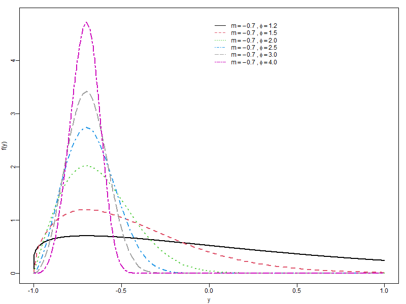

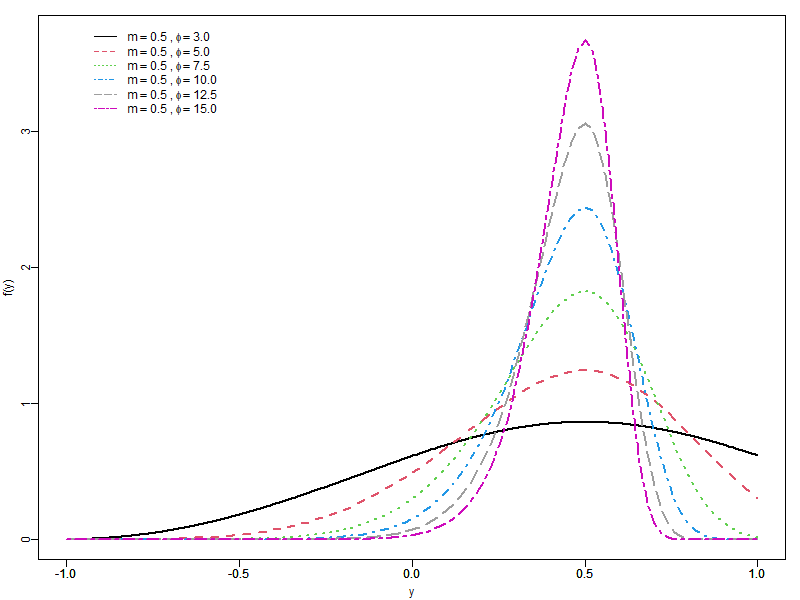

**Figure 1.** *Probability density functions of the MTW distribution under different shape parameters $\phi$, with fixed location parameters $m = -0.7$ (left) and $m = 0.5$ (right).*

### Real-world dataset

The map below provides a preliminary visualization based on electoral data, serving as a motivating example for applying the MTW model to real-world data.

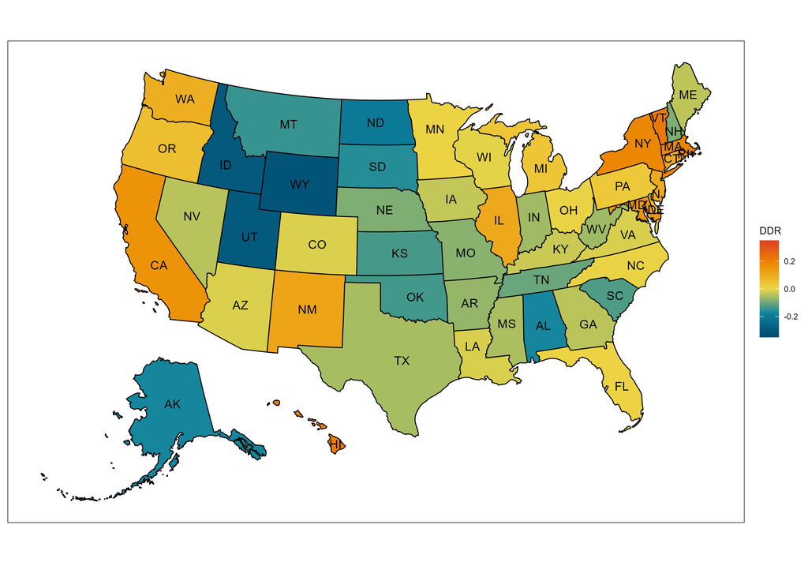

## Simulation Study Structure and Outputs

Results for each sample size `(n = 20, 30, 40, 50, 100, 200, 500)` were obtained via Monte Carlo simulations and saved in `.RData` files. These results correspond to two different scenarios (`Scenario A` and `Scenario B`) and are organized within the `Simulation/` folder as follows:

- `Simulation/simulated_data/`: contains all raw simulation outputs (.RData files), including objects such as a1, a2, …, a7, where each corresponds to a different sample size.
- `Simulation/summary_tables/`: includes processed results in .Rds format (e.g., Monte Carlo means, bias, RMSE, kurtosis, skewness) for each scenario and sample size.
- `Simulation/figures/`: stores .png files with boxplots.
- `Simulation/R/`: contains all simulation scripts and supporting functions:
- `scenarioA_simulation.R` and `scenarioB_simulation.R`: run the simulation processes for each scenario.
- `results_scenarioA.R` and `results_scenarioB.R`: perform summaries, calculations, and visualizations of the results.
- `functions_graph_summary.R`, `otimizacaoWT.R`, and `random_weibullT.R`: helper scripts used for custom random generation, model fitting, and plotting.